# Preparation

Eric Houtman, Rick Lattin, Kellen Long

We plan to use accuracy as the metric for our model performance. This metric is appropriate for our data due to the fact that the application of our models is for the classification of sentiment as purely positive or negative. The nature of the classification of this few categories makes it so that the percentage of the testing data that is guessed correctly by the classifier is what is most valuable when judging the model, as the model has no continuous range of answers to try and estimate from. Hence we use accuracy. Furthermore, the fact that the classes are polar oppposites of each other makes the use of accuracy as our metric an even more appropriate choice.

```python
import pandas as pd
import numpy as np
from tensorflow.keras.preprocessing import sequence
import os
os.environ['KMP_DUPLICATE_LIB_OK']='True'
```

```python
#read in the twitter_training.csv file and create a dataframe, using only the first 1000 rows
df = pd.read_csv('IMDB Dataset.csv', nrows=2500)
df.head()
```

|  | review | sentiment |
| --- | --- | --- |
| 0 | One of the other reviewers has mentioned that ... | positive |
| 1 | A wonderful little production. <br /><br />The... | positive |
| 2 | I thought this was a wonderful way to spend ti... | positive |
| 3 | Basically there's a family where a little boy ... | negative |
| 4 | Petter Mattei's "Love in the Time of Money" is... | positive |

```python
#check for missing values
df.isnull().sum()

#drop the missing values
df.dropna(inplace=True)

#check for missing values
df.isnull().sum()
```

```
review       0
sentiment    0
dtype: int64
```

```python
#rename the columns
df.columns = ['text', 'sentiment']

#check the dataframe
df.head()
```

|  | text | sentiment |
| --- | --- | --- |
| 0 | One of the other reviewers has mentioned that ... | positive |
| 1 | A wonderful little production. <br /><br />The... | positive |
| 2 | I thought this was a wonderful way to spend ti... | positive |
| 3 | Basically there's a family where a little boy ... | negative |
| 4 | Petter Mattei's "Love in the Time of Money" is... | positive |

We first remove any special characters from the text and split the text into individual words. This is done to improve the effectiveness and ease of the tokenization process. We also prepare a copy of the data to be used with the Glove pre-trained embedding later in the program.

```python
#remove any nun-ascii characters
df['text'] = df['text'].apply(lambda x: x.encode('ascii', 'ignore').decode('ascii'))

#make all text lowercase
df['text'] = df['text'].str.lower()

#remove any non-alphanumeric characters
df['text'] = df['text'].str.replace('[^0-9a-zA-Z]+', ' ')

#separate the text into words
df['text'] = df['text'].str.split()

#create a copy of the dataframe for later use with GloVe
df_glove = df.copy()

df_glove['sentiment'] = df_glove['sentiment'].apply(lambda x: 1 if x == 'positive' else 0)

#check the dataframe
df.head()
```

|  | text | sentiment |
| --- | --- | --- |
| 0 | [one, of, the, other, reviewers, has, mentione... | positive |
| 1 | [a, wonderful, little, production, br, br, the... | positive |
| 2 | [i, thought, this, was, a, wonderful, way, to,... | positive |
| 3 | [basically, there, s, a, family, where, a, lit... | negative |
| 4 | [petter, mattei, s, love, in, the, time, of, m... | positive |

We decided to implement a word-based method of tokenization in which we collect data regarding individual word frequency using the keras preprocessing tokenizer. This method lends itself very well to our classification task, as we are only working with text from the English language, a language that puts a lot of emphasis on individual words as opposed to strings of charcters or word-parts. Furthermore, although there are a few instances of slang or made-up words to convey meaning within the context of the reviews we are analyzing, the vast majority of the reviews rely exclusivley on the same collection of recognized English words, making the use of word based tokenization even more effective.

```python
#convert the text to integers
from keras.preprocessing.text import Tokenizer
tokenizer = Tokenizer()
tokenizer.fit_on_texts(df['text'])
df['text'] = tokenizer.texts_to_sequences(df['text'])

#make each sentiment an integer
df['sentiment'] = df['sentiment'].map({'positive': 1, 'negative': 0})


#check the dataframe
df.head()
```

|  | text | sentiment |
| --- | --- | --- |
| 0 | [30, 4, 1, 79, 1816, 47, 906, 12, 101, 149, 41... | 1 |
| 1 | [2, 354, 109, 368, 7, 7, 1, 1507, 2627, 6, 52,... | 1 |
| 2 | [10, 205, 11, 14, 2, 354, 88, 5, 1415, 63, 22,... | 1 |
| 3 | [683, 40, 13, 2, 231, 112, 2, 109, 460, 5433, ... | 0 |
| 4 | [16124, 4971, 13, 120, 9, 1, 63, 4, 281, 6, 2,... | 1 |

For this dataset, we used ShuffleSplit to partition the data. We felt this was a sufficient strategy due to the fact that the class ratioes of the testing data (positive, negative) are already at about an even split, so stratifying it is not necessary and we are able to save some computational power by implimenting shuffle split over a method that would have statified the data. We maintain a 75/25 split in the data.

```python
#split the data into training and testing sets using shuffle split
from sklearn.model_selection import ShuffleSplit
rs = ShuffleSplit(n_splits=1, test_size=.25, random_state=0)
train_index, test_index = next(rs.split(df['text']))

#create X_train, X_test, y_train, y_test
X_train = df['text'][train_index]
X_test = df['text'][test_index]
y_train = df['sentiment'][train_index]
y_test = df['sentiment'][test_index]

#check the shape of the training and testing sets
print(X_train.shape)
print(X_test.shape)
print(y_train.shape)
print(y_test.shape)
```

```
(1875,)
(625,)
(1875,)
(625,)
```

```python
# truncate and pad input sequences to be the same length
max_review_length = 500
X_train = sequence.pad_sequences(X_train, maxlen=max_review_length)
X_test = sequence.pad_sequences(X_test, maxlen=max_review_length)
```

```python
print(type(X_train), X_train.shape)
print(type(X_train[0]), X_train[0].shape)
print('Vocabulary size:', np.max(X_train))
print(y_train.shape, np.min(y_train), np.max(y_train))
NUM_CLASSES = 1
```

```
<class 'numpy.ndarray'> (1875, 500)
<class 'numpy.ndarray'> (500,)
Vocabulary size: 28090
(1875,) 0 1
```

### First Model - Simple Recurrent Neural Network

We chose standard hyperparameters for our first model as recommeneded by models given by Professor Larson. We believed they would give us a manageable run time while preventing overfitting and providing a relatively high accuracy.

```python
# show example without the FOR loop
from tensorflow.keras.models import Sequential, Model
from tensorflow.keras.layers import Dense, Input, SimpleRNN
from tensorflow.keras.layers import Embedding

EMBED_SIZE = 50
RNN_STATESIZE = 100
rnns = []
input_holder = Input(shape=(X_train.shape[1], ))
shared_embed = Embedding(np.max(X_train)+1, # vocabulary size
                EMBED_SIZE, # output dimension size
                input_length=max_review_length)(input_holder) # number of words in each sequence

x = SimpleRNN(RNN_STATESIZE, dropout=0.2, recurrent_dropout=0.2)(shared_embed)
x = Dense(NUM_CLASSES, activation='sigmoid')(x)
simple_rnn_model = Model(inputs=input_holder,outputs=x)
```

```python
from tensorflow.keras.layers import LSTM, GRU
from tensorflow.keras.optimizers import Adam
from tensorflow.keras.optimizers.schedules import ExponentialDecay

opt = Adam(lr=0.0001, epsilon=0.0001, clipnorm=1.0)

simple_rnn_model.compile(loss='binary_crossentropy',
              optimizer= opt,
              metrics=['accuracy'])

print(simple_rnn_model.summary())
```

```
WARNING:absl:`lr` is deprecated in Keras optimizer, please use `learning_rate` or use the legacy optimizer, e.g.,tf.keras.optimizers.legacy.Adam.
```

```
Model: "model_19"
_________________________________________________________________
 Layer (type)                Output Shape              Param #
=================================================================
 input_14 (InputLayer)       [(None, 500)]             0

 embedding_13 (Embedding)    (None, 500, 50)           1404550

 simple_rnn_16 (SimpleRNN)   (None, 100)               15100

 dense_21 (Dense)            (None, 1)                 101

=================================================================
Total params: 1,419,751
Trainable params: 1,419,751
Non-trainable params: 0
_________________________________________________________________
None
```

```python
history = []
tmp = simple_rnn_model.fit(X_train, y_train, batch_size=32, epochs=10, validation_data=(X_test, y_test))
history.append(tmp)
```

```python
tmp = simple_rnn_model.fit(X_train, y_train, batch_size=32, epochs=10, validation_data=(X_test, y_test))
history.append(tmp)
```

```python
tmp = simple_rnn_model.fit(X_train, y_train, batch_size=32, epochs=10, validation_data=(X_test, y_test))
history.append(tmp)
```

```python
yhat_rnn = simple_rnn_model.predict(X_test)

#print accuracy
from sklearn.metrics import accuracy_score
print('Accuracy:', accuracy_score(y_test, np.round(yhat_rnn)))
```

```
Accuracy: 0.672
```

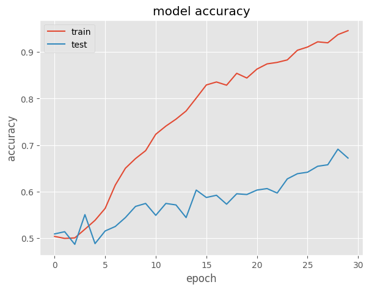

```python
# combine all the history from training together
combined = dict()
for key in ['loss', 'accuracy', 'val_loss', 'val_accuracy']:
    combined[key] = []
    for i in range(len(history)):
        combined[key].extend(history[i].history[key])

# summarize history for accuracy
plt.figure(figsize=(15,5))
plt.subplot(121)
plt.plot(combined['accuracy'])
plt.plot(combined['val_accuracy'])
plt.title('model accuracy')
plt.ylabel('accuracy')
plt.xlabel('epoch')
plt.legend(['train', 'test'], loc='upper left')
```

### Modified First Model - Different hyperparameters

The first hyperparameter we decided to change for this model was the variable EMBED_SIZE which determines the size of the embedding layer. The size of the embedding layer is doubled from 50 to 100, which increases the dimensionality of the vector representation of each word. Although this increases the amount of time needed for the training of the model, it allows the model to capture more detailed information about the text, which should improve the accuracy of the model. We chose to alter this parameter to analyze whether the change in accuracy would be worth the increase in the run time.

We also decided to change the activation function of the first dense layer of the model. We changed the activation function from the 'sigmoid' activation function to the 'relu' activation function. Although the 'sigmoid' function is primarily used with binary classifcation tasks - which is why we implemented it first - it occasionally has problems with the vanishing gradients. The 'relu' function struggles less with this and so we implemented this activation function here in order to determine whether deviating from the industry standard of activation functions for binary classification would improve the performance of our specific model by dealing with the vanishing gradient problem.

```python
EMBED_SIZE = 100
RNN_STATESIZE = 100
rnns = []
input_holder = Input(shape=(X_train.shape[1], ))
shared_embed = Embedding(np.max(X_train)+1, # vocabulary size
                EMBED_SIZE, # output dimension size
                input_length=max_review_length)(input_holder) # number of words in each sequence

x = SimpleRNN(RNN_STATESIZE, dropout=0.2, recurrent_dropout=0.2)(shared_embed)
#use a different activation function
x = Dense(NUM_CLASSES, activation='relu')(x)
modified_simple_RNN = Model(inputs=input_holder,outputs=x)
```

```python
opt = Adam(lr=0.0001, epsilon=0.0001, clipnorm=1.0)

modified_simple_RNN.compile(loss='binary_crossentropy',
              optimizer= opt,
              metrics=['accuracy'])

print(modified_simple_RNN.summary())
```

```
WARNING:absl:`lr` is deprecated in Keras optimizer, please use `learning_rate` or use the legacy optimizer, e.g.,tf.keras.optimizers.legacy.Adam.
```

```
Model: "model_20"
_________________________________________________________________
 Layer (type)                Output Shape              Param #
=================================================================
 input_15 (InputLayer)       [(None, 500)]             0

 embedding_14 (Embedding)    (None, 500, 100)          2809100

 simple_rnn_17 (SimpleRNN)   (None, 100)               20100

 dense_22 (Dense)            (None, 1)                 101

=================================================================
Total params: 2,829,301
Trainable params: 2,829,301
Non-trainable params: 0
_________________________________________________________________
None
```

```python
history = []
tmp = modified_simple_RNN.fit(X_train, y_train, batch_size=32, epochs=10, validation_data=(X_test, y_test))
history.append(tmp)
```

```python
tmp = modified_simple_RNN.fit(X_train, y_train, batch_size=32, epochs=10, validation_data=(X_test, y_test))
history.append(tmp)
```

```python
tmp = modified_simple_RNN.fit(X_train, y_train, batch_size=32, epochs=10, validation_data=(X_test, y_test))
history.append(tmp)
```

```python
yhat_rnn_mod = modified_simple_RNN.predict(X_test)
```

```
Accuracy: 0.472
```

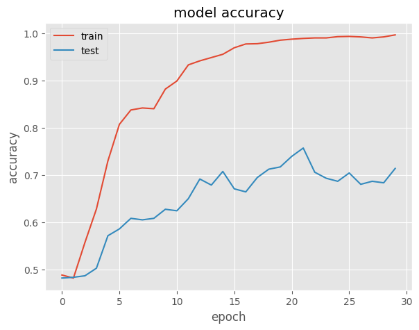

```python
import matplotlib.pyplot as plt


#plot the accuracy over the epochs using the history
from sklearn.metrics import accuracy_score
print('Accuracy:', accuracy_score(y_test, np.round(yhat_rnn_mod)))

# combine all the history from training together
combined = dict()
for key in ['loss', 'accuracy', 'val_loss', 'val_accuracy']:
    combined[key] = []
    for i in range(len(history)):
        combined[key].extend(history[i].history[key])

# summarize history for accuracy
plt.figure(figsize=(15,5))
plt.subplot(121)
plt.plot(combined['accuracy'])
plt.plot(combined['val_accuracy'])
plt.title('model accuracy')
plt.ylabel('accuracy')
plt.xlabel('epoch')
plt.legend(['train', 'test'], loc='upper left')
```

### Second Model - Long Short Term Memory

We chose standard hyperparameters for our first LSTM model as recommeneded by models given by Professor Larson. We beleieved they would give us a manageable run time while preventing overfitting, preventing vanishing gradients and providing a relatively high accuracy.

```python
from tensorflow.keras.layers import LSTM

x = LSTM(RNN_STATESIZE, dropout=0.2, recurrent_dropout=0.2)(shared_embed)
x = Dense(NUM_CLASSES, activation='sigmoid')(x)
lstm_model = Model(inputs=input_holder,outputs=x)

opt = Adam(lr=0.0001, epsilon=0.0001, clipnorm=1.0)

lstm_model.compile(loss='binary_crossentropy',
              optimizer= opt,
              metrics=['accuracy'])

print(lstm_model.summary())
```

```
WARNING:absl:`lr` is deprecated in Keras optimizer, please use `learning_rate` or use the legacy optimizer, e.g.,tf.keras.optimizers.legacy.Adam.
```

```
Model: "model_21"
_________________________________________________________________
 Layer (type)                Output Shape              Param #
=================================================================
 input_15 (InputLayer)       [(None, 500)]             0

 embedding_14 (Embedding)    (None, 500, 100)          2809100

 lstm_5 (LSTM)               (None, 100)               80400

 dense_23 (Dense)            (None, 1)                 101

=================================================================
Total params: 2,889,601
Trainable params: 2,889,601
Non-trainable params: 0
_________________________________________________________________
None
```

```python
history = []
tmp = lstm_model.fit(X_train, y_train, epochs=3, batch_size=64, validation_data=(X_test, y_test))
history.append(tmp)
```

```python
tmp = lstm_model.fit(X_train, y_train, epochs=3, batch_size=64, validation_data=(X_test, y_test))
history.append(tmp)
```

```python
yhat_lstm = lstm_model.predict(X_test)
```

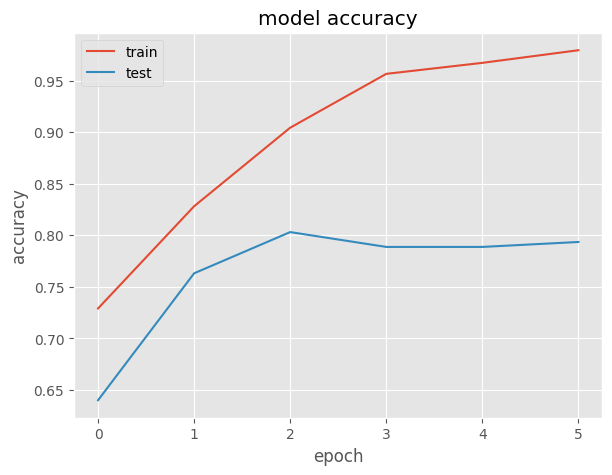

```python
# combine all the history from training together
combined = dict()
for key in ['accuracy','val_accuracy','loss','val_loss']:
    combined[key] = np.hstack([x.history[key] for x in history])

# summarize history for accuracy
plt.figure(figsize=(15,5))
plt.subplot(121)
plt.plot(combined['accuracy'])
plt.plot(combined['val_accuracy'])
plt.title('model accuracy')
plt.ylabel('accuracy')
plt.xlabel('epoch')
plt.legend(['train', 'test'], loc='upper left')
```

### Modified Second Model - Different hyperparameters

The only hyperparameter we decided to change for this model was the activation fucntion of the first dense layer of the LSTM model. We changed the activation function from the 'sigmoid' activation function to the 'relu' activation function. As we mentioned earlier, although the 'sigmoid' function is primarily used with binary classifcation tasks - which is why we implemented it first - it occasionally has problems with the vanishing gradients. The 'relu' function struggles less with this and so we implemented this activation function here in order to determine whether deviating from the industry standard of activation functions for binary classification would improve the performance of our specific model by dealing with the vanishing gradient problem.

```python
#create a new lstm model with different hyperparameters
from tensorflow.keras.layers import LSTM

x = LSTM(RNN_STATESIZE, dropout=0.2, recurrent_dropout=0.2)(shared_embed)
x = Dense(NUM_CLASSES, activation='relu')(x)
modified_lstm_model = Model(inputs=input_holder,outputs=x)

opt = Adam(lr=0.0001, epsilon=0.0001, clipnorm=1.0)

modified_lstm_model.compile(loss='binary_crossentropy',
                optimizer= opt,
                metrics=['accuracy'])

print(modified_lstm_model.summary())
```

```
WARNING:absl:`lr` is deprecated in Keras optimizer, please use `learning_rate` or use the legacy optimizer, e.g.,tf.keras.optimizers.legacy.Adam.
```

```
Model: "model_22"
_________________________________________________________________
 Layer (type)                Output Shape              Param #
=================================================================
 input_15 (InputLayer)       [(None, 500)]             0

 embedding_14 (Embedding)    (None, 500, 100)          2809100

 lstm_6 (LSTM)               (None, 100)               80400

 dense_24 (Dense)            (None, 1)                 101

=================================================================
Total params: 2,889,601
Trainable params: 2,889,601
Non-trainable params: 0
_________________________________________________________________
None
```

```python
history = []
tmp = modified_lstm_model.fit(X_train, y_train, epochs=3, batch_size=64, validation_data=(X_test, y_test))
history.append(tmp)
```

```python
tmp = modified_lstm_model.fit(X_train, y_train, epochs=3, batch_size=64, validation_data=(X_test, y_test))
history.append(tmp)
```

```python
yhat_lstm_mod = modified_lstm_model.predict(X_test)
```

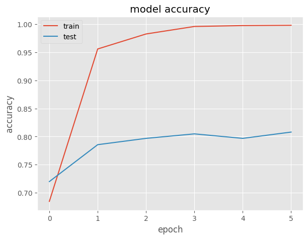

```python
# combine all the history from training together
combined = dict()
for key in ['accuracy','val_accuracy','loss','val_loss']:
    combined[key] = np.hstack([x.history[key] for x in history])

# summarize history for accuracy
plt.figure(figsize=(15,5))
plt.subplot(121)
plt.plot(combined['accuracy'])
plt.plot(combined['val_accuracy'])
plt.title('model accuracy')
plt.ylabel('accuracy')
plt.xlabel('epoch')
plt.legend(['train', 'test'], loc='upper left')
```

### Overall Comparison of Accuracy

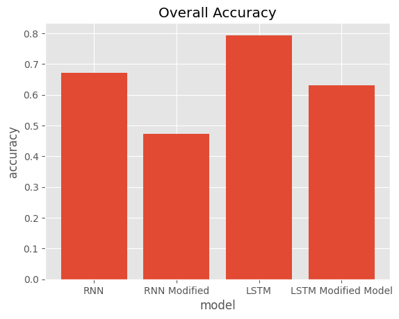

```python
from sklearn import metrics as mt
from matplotlib import pyplot as plt
%matplotlib inline

acc = [mt.accuracy_score(y_test,np.round(yhat_rnn)),
       mt.accuracy_score(y_test,np.round(yhat_rnn_mod)),
       mt.accuracy_score(y_test,np.round(yhat_lstm)),
       mt.accuracy_score(y_test,np.round(yhat_lstm_mod))]

plt.ylabel('accuracy')
plt.xlabel('model')
plt.title('Overall Accuracy')
plt.bar(['RNN','RNN Modified','LSTM', 'LSTM Modified Model' ],acc)
plt.show()
```

### Adding an additional recurrent layer

```python
#add a second recurrent chain to the RNN model
from tensorflow.keras.layers import LSTM

x = SimpleRNN(RNN_STATESIZE, dropout=0.2, recurrent_dropout=0.2, return_sequences=True)(shared_embed)
x = SimpleRNN(RNN_STATESIZE, dropout=0.2, recurrent_dropout=0.2)(x)
x = Dense(NUM_CLASSES, activation='sigmoid')(x)

lstm_model2 = Model(inputs=input_holder,outputs=x)

opt = Adam(lr=0.0001, epsilon=0.0001, clipnorm=1.0)

lstm_model2.compile(loss='binary_crossentropy',
                optimizer= opt,
                metrics=['accuracy'])

print(lstm_model2.summary())
```

```
WARNING:absl:`lr` is deprecated in Keras optimizer, please use `learning_rate` or use the legacy optimizer, e.g.,tf.keras.optimizers.legacy.Adam.
```

```
Model: "model_23"
_________________________________________________________________
 Layer (type)                Output Shape              Param #
=================================================================
 input_15 (InputLayer)       [(None, 500)]             0

 embedding_14 (Embedding)    (None, 500, 100)          2809100

 simple_rnn_18 (SimpleRNN)   (None, 500, 100)          20100

 simple_rnn_19 (SimpleRNN)   (None, 100)               20100

 dense_25 (Dense)            (None, 1)                 101

=================================================================
Total params: 2,849,401
Trainable params: 2,849,401
Non-trainable params: 0
_________________________________________________________________
None
```

```python
history = []
tmp = lstm_model2.fit(X_train, y_train, epochs=3, batch_size=64, validation_data=(X_test, y_test))
history.append(tmp)
```

```python
tmp = lstm_model2.fit(X_train, y_train, epochs=3, batch_size=64, validation_data=(X_test, y_test))
history.append(tmp)
```

```python
tmp = lstm_model2.fit(X_train, y_train, epochs=3, batch_size=64, validation_data=(X_test, y_test))
history.append(tmp)
```

```python
yhat_lstm2 = lstm_model2.predict(X_test)
```

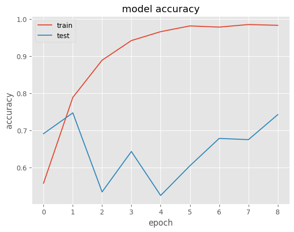

```python
# combine all the history from training together
combined = dict()
for key in ['accuracy','val_accuracy','loss','val_loss']:
    combined[key] = np.hstack([x.history[key] for x in history])

# summarize history for accuracy
plt.figure(figsize=(15,5))
plt.subplot(121)
plt.plot(combined['accuracy'])
plt.plot(combined['val_accuracy'])
plt.title('model accuracy')
plt.ylabel('accuracy')
plt.xlabel('epoch')
plt.legend(['train', 'test'], loc='upper left')
```

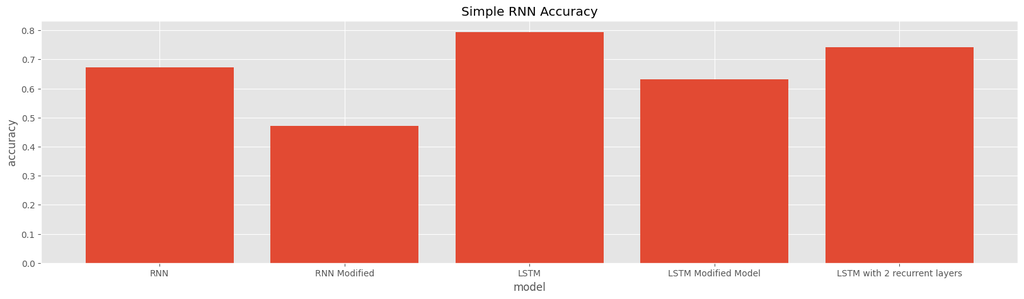

```python
from sklearn import metrics as mt
from matplotlib import pyplot as plt
%matplotlib inline

acc = [mt.accuracy_score(y_test,np.round(yhat_rnn)),
       mt.accuracy_score(y_test,np.round(yhat_rnn_mod)),
       mt.accuracy_score(y_test,np.round(yhat_lstm)),
       mt.accuracy_score(y_test,np.round(yhat_lstm_mod)),
       mt.accuracy_score(y_test,np.round(yhat_lstm2))]

plt.figure(figsize=(20,5))
plt.ylabel('accuracy')
plt.xlabel('model')
plt.title('Simple RNN Accuracy')
plt.bar(['RNN','RNN Modified','LSTM', 'LSTM Modified Model', 'LSTM with 2 recurrent layers' ],acc)
plt.show()
```

## Glove Embeddings

```python
%%time
from tensorflow import keras
from tensorflow.keras.preprocessing.text import Tokenizer
from tensorflow.keras.preprocessing.sequence import pad_sequences

NUM_TOP_WORDS = None # use entire vocabulary!
MAX_ART_LEN = 1000 # maximum and minimum number of words

tokenizer = Tokenizer(num_words=NUM_TOP_WORDS)
tokenizer.fit_on_texts(df_glove['text'])

word_index = tokenizer.word_index
NUM_TOP_WORDS = len(word_index) if NUM_TOP_WORDS is None else NUM_TOP_WORDS
top_words = min((len(word_index),NUM_TOP_WORDS))
print('Found %s unique tokens. Distilled to %d top words.' % (len(word_index),top_words))

X = pad_sequences(tokenizer.texts_to_sequences(df_glove['text']), maxlen=MAX_ART_LEN)
y = df_glove['sentiment'].values

y_ohe = keras.utils.to_categorical(y, 2)

print('Shape of data tensor:', X.shape)
print('Shape of label tensor:', y_ohe.shape)
print(np.max(X))
```

```
Found 28090 unique tokens. Distilled to 28090 top words.
Shape of data tensor: (2500, 1000)
Shape of label tensor: (2500, 2)
28090
CPU times: total: 172 ms
Wall time: 367 ms
```

```
X_train Shape: (2000, 1000) Label Shape: (2000, 2)
```

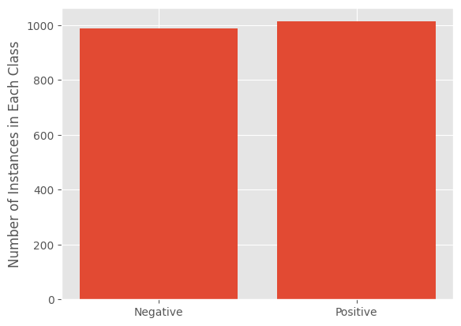

```python
from sklearn.model_selection import train_test_split
from sklearn import metrics as mt
from matplotlib import pyplot as plt
%matplotlib inline

X_train, X_test, y_train_ohe, y_test_ohe = train_test_split(X, y_ohe, test_size=0.2,
                                                            stratify=y,
                                                            random_state=42)

NUM_CLASSES = 2

# print some stats of the data
print("X_train Shape:",X_train.shape, "Label Shape:", y_train_ohe.shape)
uniq_classes = np.sum(y_train_ohe,axis=0)
plt.bar(list(range(2)),uniq_classes)
plt.xticks(list(range(2)), ['Negative','Positive'])
plt.ylabel("Number of Instances in Each Class")
plt.show()
```

```python
%%time
EMBED_SIZE = 100
# the embed size should match the file you load glove from
embeddings_index = {}
f = open('glove/glove.6B.100d.txt', encoding='utf8')
print('Loading GloVe from:', f.name,'...this may take a while...')
for line in f:
    values = line.split()
    word = values[0]
    coefs = np.asarray(values[1:], dtype='float32') # shape (300,)
    embeddings_index[word] = coefs
f.close()
print('Found %s word vectors.' % len(embeddings_index))

found_words = 0
embedding_matrix = np.zeros((len(word_index) + 1, EMBED_SIZE))
for word, i in word_index.items():
    embedding_vector = embeddings_index.get(word)
    if embedding_vector is not None:
        # words not found in embedding index will be ALL-ZEROS
        embedding_matrix[i] = embedding_vector
        found_words = found_words+1

print("Embedding Shape:",embedding_matrix.shape, "\n",
      "Total words found:",found_words, "\n",
      "Percentage:",100*found_words/embedding_matrix.shape[0])
```

```
Loading GloVe from: glove/glove.6B.100d.txt ...this may take a while...
Found 400000 word vectors.
Embedding Shape: (28091, 100)
 Total words found: 26331
 Percentage: 93.73464810793493
CPU times: total: 1.47 s
Wall time: 6.77 s
```

```python
from tensorflow.keras.layers import Embedding

# save this embedding now
embedding_layer = Embedding(len(word_index) + 1,
                            EMBED_SIZE,
                            weights=[embedding_matrix],# here is the embedding getting saved
                            input_length=MAX_ART_LEN,
                            trainable=False)
```

```python
from tensorflow.keras.models import Sequential
from tensorflow.keras.layers import Dense
from tensorflow.keras.layers import LSTM

rnn = Sequential()
rnn.add(embedding_layer)
rnn.add(LSTM(100,dropout=0.2, recurrent_dropout=0.2))
rnn.add(Dense(NUM_CLASSES, activation='sigmoid'))
rnn.compile(loss='categorical_crossentropy',
              optimizer='rmsprop',
              metrics=['accuracy'])
print(rnn.summary())
```

```
Model: "sequential_1"
_________________________________________________________________
 Layer (type)                Output Shape              Param #
=================================================================
 embedding_15 (Embedding)    (None, 1000, 100)         2809100

 lstm_7 (LSTM)               (None, 100)               80400

 dense_26 (Dense)            (None, 2)                 202

=================================================================
Total params: 2,889,702
Trainable params: 80,602
Non-trainable params: 2,809,100
_________________________________________________________________
None
```

```python
history = []
tmp = rnn.fit(X_train, y_train_ohe, validation_data=(X_test, y_test_ohe), epochs=6, batch_size=64)
history.append( tmp )
```

We were not able to train this model to true convergence like we attempted to do for the other graphs. This was only the case due to the fact that this model took drastically longer to run than the rest of the models, taking upwards of an hour to run 6 epochs.

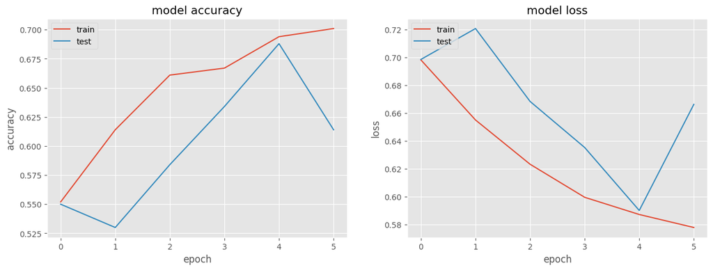

```python
# combine all the history from training together
combined = dict()
for key in ['accuracy','val_accuracy','loss','val_loss']:
    combined[key] = np.hstack([x.history[key] for x in history])

# summarize history for accuracy
plt.figure(figsize=(15,5))
plt.subplot(121)
plt.plot(combined['accuracy'])
plt.plot(combined['val_accuracy'])
plt.title('model accuracy')
plt.ylabel('accuracy')
plt.xlabel('epoch')
plt.legend(['train', 'test'], loc='upper left')

# summarize history for loss
plt.subplot(122)
plt.plot(combined['loss'])
plt.plot(combined['val_loss'])
plt.title('model loss')
plt.ylabel('loss')
plt.xlabel('epoch')
plt.legend(['train', 'test'], loc='upper left')
plt.show()
```

```python
#predict with the model
yhat_rnn_glove = rnn.predict(X_test)
```

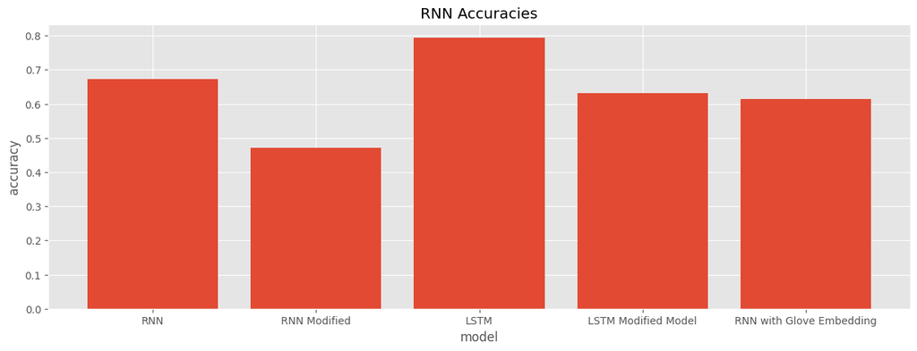

```python
from sklearn import metrics as mt
from matplotlib import pyplot as plt
%matplotlib inline

acc = [mt.accuracy_score(y_test,np.round(yhat_rnn)),
       mt.accuracy_score(y_test,np.round(yhat_rnn_mod)),
       mt.accuracy_score(y_test,np.round(yhat_lstm)),
       mt.accuracy_score(y_test,np.round(yhat_lstm_mod)),
       mt.accuracy_score(np.argmax(y_test_ohe,axis=1),np.argmax(yhat_rnn_glove,axis=1))]


plt.figure(figsize=(15,5))
plt.ylabel('accuracy')
plt.xlabel('model')
plt.title('RNN Accuracies')
plt.bar(['RNN','RNN Modified','LSTM', 'LSTM Modified Model', 'RNN with Glove Embedding' ],acc)
plt.show()
```

## Grad Section - Converting back to Convolutional Neural Network

```python
from tensorflow.keras.models import Model
from tensorflow.keras.layers import Conv1D, MaxPooling1D, Flatten, Dense
from tensorflow.keras.layers import Dense, Input, Dropout
from tensorflow.keras.layers import Embedding

EMBED_SIZE = 100
sequence_input = Input(shape=(MAX_ART_LEN,), dtype='int32')
# starting size: 1000
embedded_sequences = embedding_layer(sequence_input) # from previous embedding
x = Conv1D(128, 5, activation='relu',
           kernel_initializer='he_uniform')(embedded_sequences)

# after conv, size becomes: 1000-4=996
x = Dropout(0.05)(x)
x = MaxPooling1D(5)(x)# after max pool, 996/5 = 199
x = Dropout(0.15)(x)
x = Conv1D(128, 5, activation='relu',
           kernel_initializer='he_uniform')(x)

# new size is 195
x = MaxPooling1D(5)(x) # after max pool, size is 195/5 = 39
x = Dropout(0.2)(x)
x = Conv1D(128, 5, activation='relu',
           kernel_initializer='he_uniform')(x)

# after convolution, size becomes 35 elements long
x = MaxPooling1D(35)(x) # this is the size to globally flatten
# flattened vector max pools across each of the 35 elements
# so vectors is now 128 dimensions (same as num output filters)
x = Flatten()(x)
x = Dropout(0.25)(x)
x = Dense(128, activation='relu',
          kernel_initializer='he_uniform')(x)

preds = Dense(NUM_CLASSES, activation='softmax',
              kernel_initializer='glorot_uniform')(x)

model = Model(sequence_input, preds)
model.compile(loss='categorical_crossentropy',
              optimizer='rmsprop',
              metrics=['acc'])

print(model.summary())
histories = []
tmp = model.fit(X_train, y_train_ohe, validation_data=(X_test, y_test_ohe),
          epochs=2, batch_size=128)
histories.append(tmp)
```

```
Model: "model_24"
_________________________________________________________________
 Layer (type)                Output Shape              Param #
=================================================================
 input_16 (InputLayer)       [(None, 1000)]            0

 embedding_15 (Embedding)    (None, 1000, 100)         2809100

 conv1d_3 (Conv1D)           (None, 996, 128)          64128

 dropout_4 (Dropout)         (None, 996, 128)          0

 max_pooling1d_3 (MaxPooling  (None, 199, 128)         0
 1D)

 dropout_5 (Dropout)         (None, 199, 128)          0

 conv1d_4 (Conv1D)           (None, 195, 128)          82048

 max_pooling1d_4 (MaxPooling  (None, 39, 128)          0
 1D)

 dropout_6 (Dropout)         (None, 39, 128)           0

 conv1d_5 (Conv1D)           (None, 35, 128)           82048

 max_pooling1d_5 (MaxPooling  (None, 1, 128)           0
 1D)

 flatten_1 (Flatten)         (None, 128)               0

 dropout_7 (Dropout)         (None, 128)               0

 dense_27 (Dense)            (None, 128)               16512

 dense_28 (Dense)            (None, 2)                 258

=================================================================
Total params: 3,054,094
Trainable params: 244,994
Non-trainable params: 2,809,100
_________________________________________________________________
None
```

```python
tmp = model.fit(X_train, y_train_ohe, validation_data=(X_test, y_test_ohe),
          epochs=10, batch_size=128)
histories.append(tmp)
```

```python
tmp = model.fit(X_train, y_train_ohe, validation_data=(X_test, y_test_ohe),
          epochs=10, batch_size=128)
histories.append(tmp)
```

```python
tmp = model.fit(X_train, y_train_ohe, validation_data=(X_test, y_test_ohe),
          epochs=10, batch_size=128)
histories.append(tmp)
```

```python
tmp = model.fit(X_train, y_train_ohe, validation_data=(X_test, y_test_ohe),
          epochs=10, batch_size=128)
histories.append(tmp)
```

```python
tmp = model.fit(X_train, y_train_ohe, validation_data=(X_test, y_test_ohe),
          epochs=10, batch_size=128)
histories.append(tmp)
```

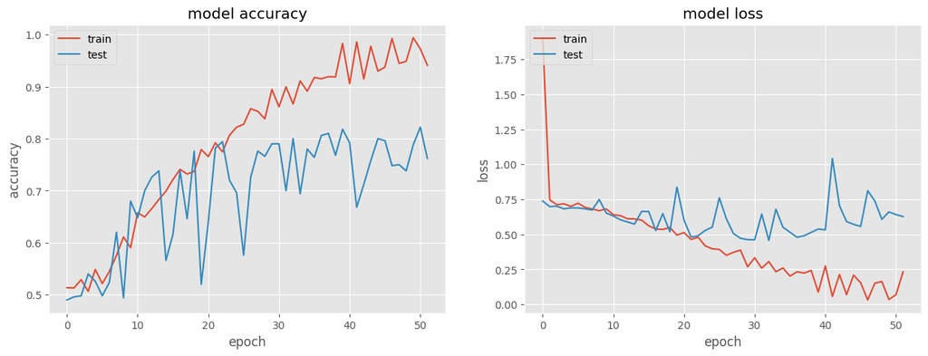

```python
from sklearn import metrics as mt
from matplotlib import pyplot as plt
%matplotlib inline

# combine all the history from training together
combined = dict()
for key in ['acc','val_acc','loss','val_loss']:
    combined[key] = np.hstack([x.history[key] for x in histories])

# summarize history for accuracy
plt.figure(figsize=(15,5))
plt.subplot(121)
plt.plot(combined['acc'])
plt.plot(combined['val_acc'])
plt.title('model accuracy')
plt.ylabel('accuracy')
plt.xlabel('epoch')
plt.legend(['train', 'test'], loc='upper left')

# summarize history for loss
plt.subplot(122)
plt.plot(combined['loss'])
plt.plot(combined['val_loss'])
plt.title('model loss')
plt.ylabel('loss')
plt.xlabel('epoch')
plt.legend(['train', 'test'], loc='upper left')
plt.show()
```

```python
#predict with the model
yhat_cnn = model.predict(X_test)
```

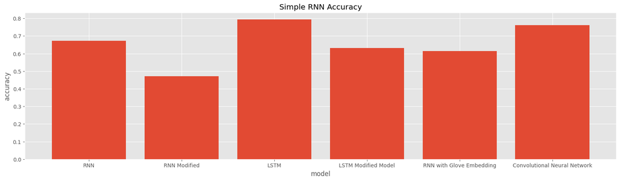

```python
from sklearn import metrics as mt
from matplotlib import pyplot as plt
%matplotlib inline

acc = [mt.accuracy_score(y_test,np.round(yhat_rnn)),
       mt.accuracy_score(y_test,np.round(yhat_rnn_mod)),
       mt.accuracy_score(y_test,np.round(yhat_lstm)),
       mt.accuracy_score(y_test,np.round(yhat_lstm_mod)),
       mt.accuracy_score(np.argmax(y_test_ohe,axis=1),np.argmax(yhat_rnn_glove,axis=1)),
       mt.accuracy_score(np.argmax(y_test_ohe,axis=1),np.argmax(yhat_cnn,axis=1))]


plt.figure(figsize=(20,5))
plt.ylabel('accuracy')
plt.xlabel('model')
plt.title('Simple RNN Accuracy')
plt.bar(['RNN','RNN Modified','LSTM', 'LSTM Modified Model', 'RNN with Glove Embedding', 'Convolutional Neural Network' ],acc)
plt.show()
```